# Assigment 2

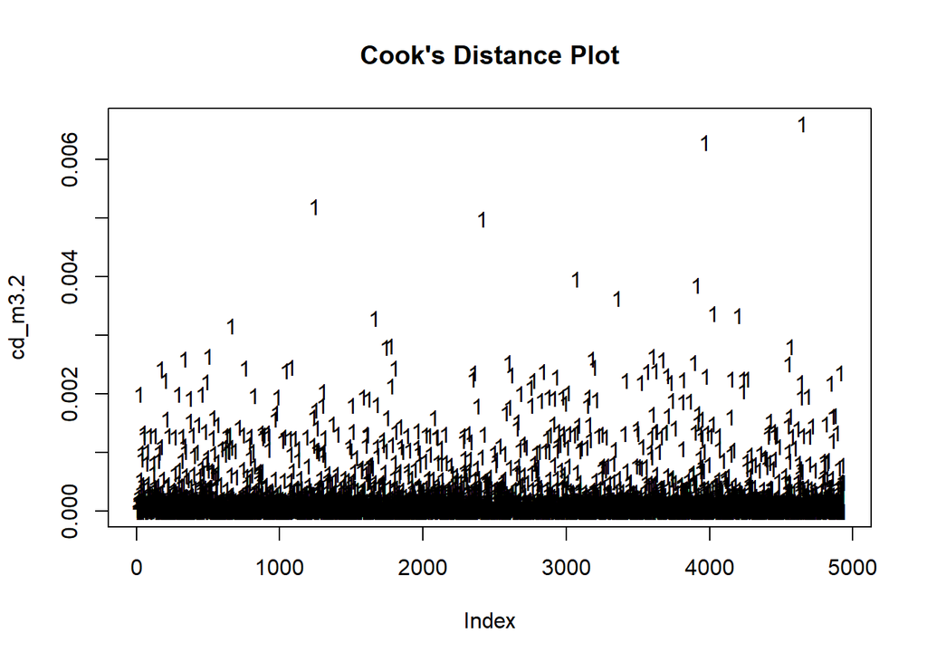

```r
# Calculate Cook's distance
cd_m3.2 <- cooks.distance(mod3.2)

# Plot Cook's distance
plot(cd_m3.2, pch = "18", main = "Cook's Distance Plot")
abline(h = 4/(length(mod3.2$coefficients) - 1), col = "red")
```

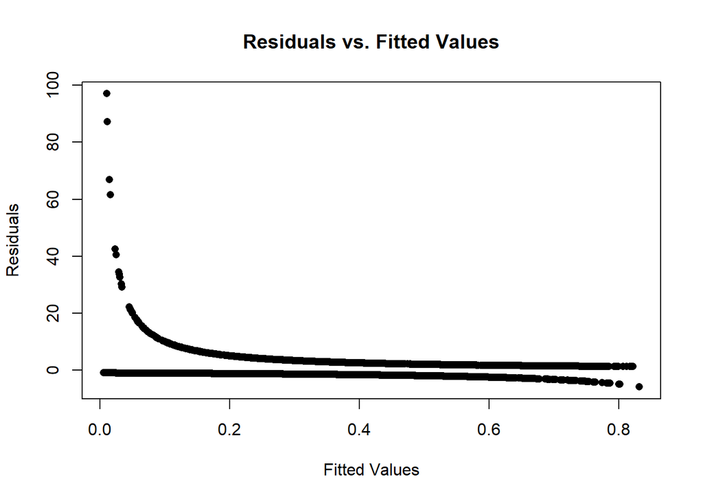

```r
#Check homoscedasticity (constant variance of residuals) by plotting residuals against fitted values:

# Plotting residuals against fitted values

plot(fitted(mod3.2), res_3.2, pch = 16, main = "Residuals vs. Fitted Values", xlab = "Fitted Values", ylab = "Residuals")
```

##Categorical Variables

Now, we shall add the categorical variables. The order of addition is significant, therefore we start by adding the most correlated variables with the target.

Contract InternetService StreamingMovies StreamingTV TechSupport DeviceProtection OnlineBackup OnlineSecurity PaperlessBilling Dependents MultipleLines SeniorCitizen Partner PaymentMethod PhoneService

#Contract

We start with *Contract* variable.

```r
mod4 <- glm(Churn ~ tenure + MonthlyCharges + Contract, data=train, family=binomial)
summary(mod4) #4302.2 better
```

```
##
## Call:
## glm(formula = Churn ~ tenure + MonthlyCharges + Contract, family = binomial,
##     data = train)
##
## Coefficients:
##                   Estimate Std. Error z value Pr(>|z|)
## (Intercept)      -1.687949   0.109108 -15.470   <2e-16 ***
## tenure           -0.035614   0.002450 -14.534   <2e-16 ***
## MonthlyCharges    0.029457   0.001632  18.047   <2e-16 ***
## ContractOne year -1.050590   0.120126  -8.746   <2e-16 ***
## ContractTwo year -2.082901   0.204897 -10.166   <2e-16 ***
## ---
## Signif. codes:  0 '***' 0.001 '**' 0.01 '*' 0.05 '.' 0.1 ' ' 1
##
## (Dispersion parameter for binomial family taken to be 1)
##
##     Null deviance: 5694.2  on 4929  degrees of freedom
## Residual deviance: 4292.2  on 4925  degrees of freedom
## AIC: 4302.2
##
## Number of Fisher Scoring iterations: 6
```

```r
anova( mod3.2, mod4,  test="Chisq") #significant
```

```
## Analysis of Deviance Table
##
## Model 1: Churn ~ tenure + MonthlyCharges
## Model 2: Churn ~ tenure + MonthlyCharges + Contract
##   Resid. Df Resid. Dev Df Deviance  Pr(>Chi)
## 1      4927     4467.5
## 2      4925     4292.2  2   175.22 < 2.2e-16 ***
## ---
## Signif. codes:  0 '***' 0.001 '**' 0.01 '*' 0.05 '.' 0.1 ' ' 1
```

```r
vif(mod4)
```

```
##                    GVIF Df GVIF^(1/(2*Df))
## tenure         1.707900  1        1.306867
## MonthlyCharges 1.300967  1        1.140599
## Contract       1.361428  2        1.080186
```

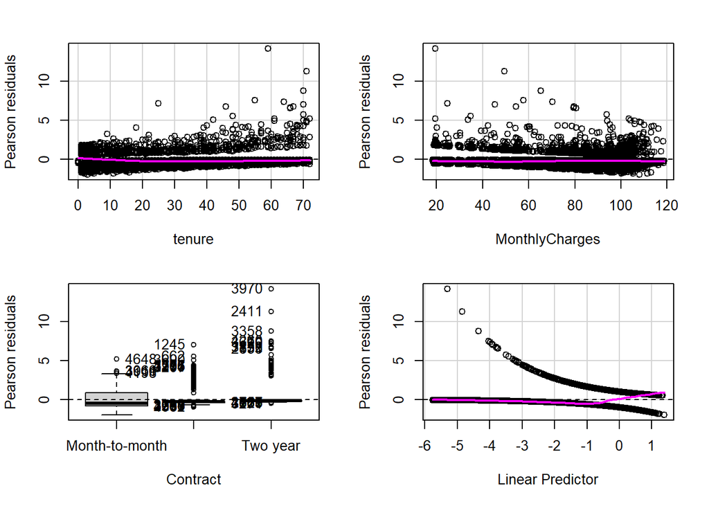

```
##                Test stat Pr(>|Test stat|)
## tenure           53.7553         2.27e-13 ***
## MonthlyCharges    1.7946           0.1804
## Contract
## ---
## Signif. codes:  0 '***' 0.001 '**' 0.01 '*' 0.05 '.' 0.1 ' ' 1
```

```r
residualPlots(mod4)
```

We add the parameter because it improves the model.

#InternetService

```r
mod5 <- glm(Churn ~ tenure + MonthlyCharges + Contract + InternetService, data=train, family=binomial)
summary(mod5) #4254.1 better
```

```
##
## Call:
## glm(formula = Churn ~ tenure + MonthlyCharges + Contract + InternetService,
##     family = binomial, data = train)
##
## Coefficients:
##                             Estimate Std. Error z value Pr(>|z|)
## (Intercept)                -0.643248   0.186158  -3.455  0.00055 ***
## tenure                     -0.032148   0.002479 -12.969  < 2e-16 ***
## MonthlyCharges              0.006365   0.003559   1.788  0.07373 .
## ContractOne year           -0.865294   0.123069  -7.031 2.05e-12 ***
## ContractTwo year           -1.804983   0.208329  -8.664  < 2e-16 ***
## InternetServiceFiber optic  0.980860   0.149013   6.582 4.63e-11 ***
## InternetServiceNo          -0.895142   0.181620  -4.929 8.28e-07 ***
## ---
## Signif. codes:  0 '***' 0.001 '**' 0.01 '*' 0.05 '.' 0.1 ' ' 1
##
## (Dispersion parameter for binomial family taken to be 1)
##
##     Null deviance: 5694.2  on 4929  degrees of freedom
## Residual deviance: 4240.1  on 4923  degrees of freedom
## AIC: 4254.1
##
## Number of Fisher Scoring iterations: 6
```

```r
anova( mod4, mod5,  test="Chisq") #significant
```

```
## Analysis of Deviance Table
##
## Model 1: Churn ~ tenure + MonthlyCharges + Contract
## Model 2: Churn ~ tenure + MonthlyCharges + Contract + InternetService
##   Resid. Df Resid. Dev Df Deviance  Pr(>Chi)
## 1      4925     4292.2
## 2      4923     4240.1  2    52.12 4.811e-12 ***
## ---
## Signif. codes:  0 '***' 0.001 '**' 0.01 '*' 0.05 '.' 0.1 ' ' 1
```

```r
vif(mod5)
```

```
##                     GVIF Df GVIF^(1/(2*Df))
## tenure          1.738643  1        1.318576
## MonthlyCharges  6.009378  1        2.451403
## Contract        1.450931  2        1.097518
## InternetService 5.338238  2        1.520021
```

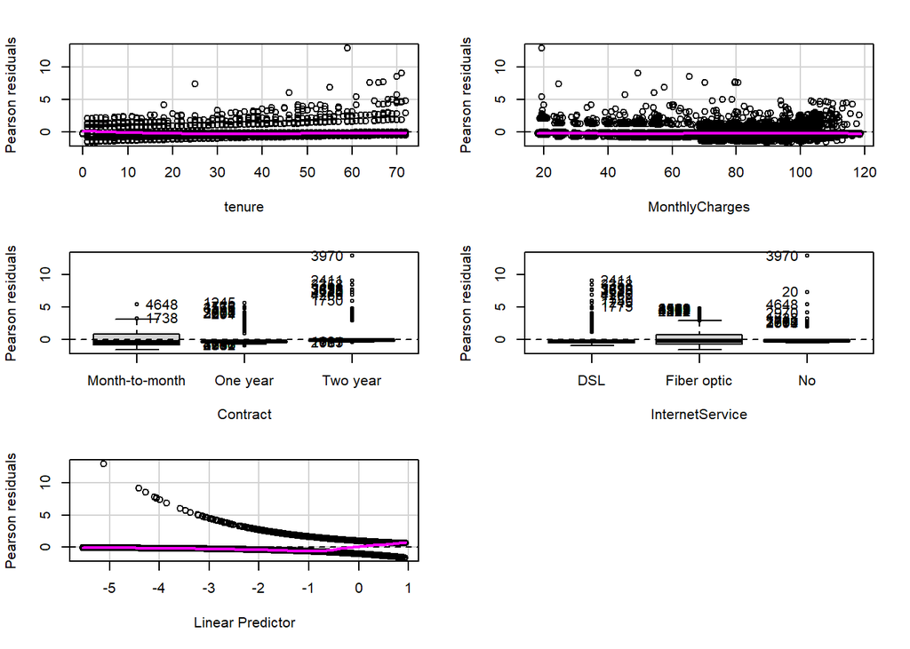

```
##                 Test stat Pr(>|Test stat|)
## tenure             49.365        2.125e-12 ***
## MonthlyCharges     26.266        2.975e-07 ***
## Contract
## InternetService
## ---
## Signif. codes:  0 '***' 0.001 '**' 0.01 '*' 0.05 '.' 0.1 ' ' 1
```

```r
residualPlots(mod5)
```

#StreamingMovies

```r
mod6 <- glm(Churn ~ tenure + MonthlyCharges + Contract + InternetService + StreamingMovies, data=train, family=binomial)
summary(mod6) #4238.6 better
```

```
##
## Call:
## glm(formula = Churn ~ tenure + MonthlyCharges + Contract + InternetService +
##     StreamingMovies, family = binomial, data = train)
##
## Coefficients:
##                             Estimate Std. Error z value Pr(>|z|)
## (Intercept)                -0.219913   0.209784  -1.048    0.295
## tenure                     -0.031968   0.002480 -12.888  < 2e-16 ***
## MonthlyCharges             -0.004380   0.004374  -1.001    0.317
## ContractOne year           -0.870117   0.123320  -7.056 1.72e-12 ***
## ContractTwo year           -1.795490   0.208231  -8.623  < 2e-16 ***
## InternetServiceFiber optic  1.282307   0.167023   7.677 1.62e-14 ***
## InternetServiceNo          -1.100410   0.186826  -5.890 3.86e-09 ***
## StreamingMoviesYes          0.441326   0.105641   4.178 2.95e-05 ***
## ---
## Signif. codes:  0 '***' 0.001 '**' 0.01 '*' 0.05 '.' 0.1 ' ' 1
##
## (Dispersion parameter for binomial family taken to be 1)
##
##     Null deviance: 5694.2  on 4929  degrees of freedom
## Residual deviance: 4222.6  on 4922  degrees of freedom
## AIC: 4238.6
##
## Number of Fisher Scoring iterations: 6
```

```r
anova( mod5, mod6,  test="Chisq") #significant
```

```
## Analysis of Deviance Table
##
## Model 1: Churn ~ tenure + MonthlyCharges + Contract + InternetService
## Model 2: Churn ~ tenure + MonthlyCharges + Contract + InternetService +
##     StreamingMovies
##   Resid. Df Resid. Dev Df Deviance Pr(>Chi)
## 1      4923     4240.1
## 2      4922     4222.6  1   17.563 2.78e-05 ***
## ---
## Signif. codes:  0 '***' 0.001 '**' 0.01 '*' 0.05 '.' 0.1 ' ' 1
```

```r
vif(mod6)
```

```
##                     GVIF Df GVIF^(1/(2*Df))
## tenure          1.734387  1        1.316961
## MonthlyCharges  9.114445  1        3.019014
## Contract        1.447519  2        1.096872
## InternetService 6.680296  2        1.607677
## StreamingMovies 1.878425  1        1.370556
```

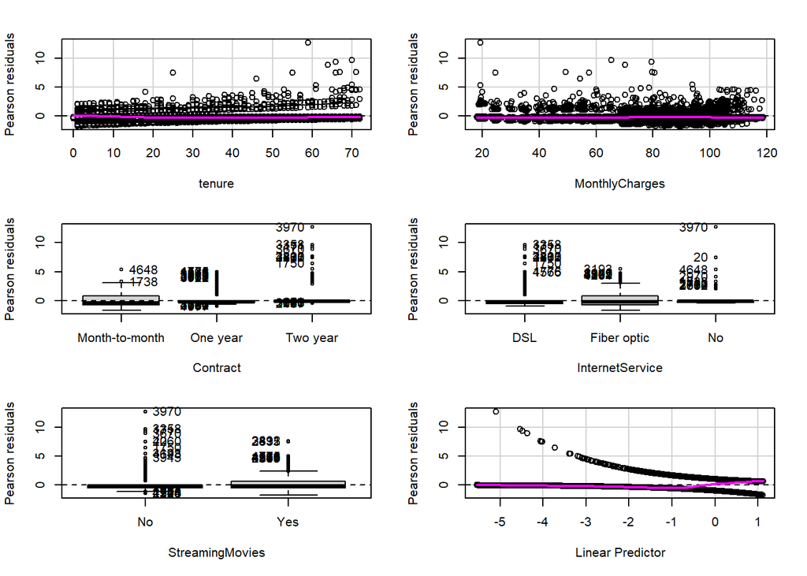

```
##                 Test stat Pr(>|Test stat|)
## tenure               49.6        1.885e-12 ***
## MonthlyCharges       17.2        3.364e-05 ***
## Contract
## InternetService
## StreamingMovies
## ---
## Signif. codes:  0 '***' 0.001 '**' 0.01 '*' 0.05 '.' 0.1 ' ' 1
```

```r
residualPlots(mod6)
```

The model has improved but the VIF is becoming higher.

#StreamingTV

```r
mod7 <- glm(Churn ~ tenure + MonthlyCharges + Contract + InternetService + StreamingMovies + StreamingTV, data=train, family=binomial)
summary(mod7) #4213.5 better
```

```
##
## Call:
## glm(formula = Churn ~ tenure + MonthlyCharges + Contract + InternetService +
##     StreamingMovies + StreamingTV, family = binomial, data = train)
##
## Coefficients:
##                             Estimate Std. Error z value Pr(>|z|)
## (Intercept)                 0.311672   0.230322   1.353 0.175990
## tenure                     -0.031969   0.002487 -12.855  < 2e-16 ***
## MonthlyCharges             -0.017752   0.005047  -3.517 0.000436 ***
## ContractOne year           -0.870522   0.123651  -7.040 1.92e-12 ***
## ContractTwo year           -1.775038   0.208250  -8.524  < 2e-16 ***
## InternetServiceFiber optic  1.650173   0.183107   9.012  < 2e-16 ***
## InternetServiceNo          -1.359915   0.191532  -7.100 1.25e-12 ***
## StreamingMoviesYes          0.445782   0.105508   4.225 2.39e-05 ***
## StreamingTVYes              0.552871   0.106924   5.171 2.33e-07 ***
## ---
## Signif. codes:  0 '***' 0.001 '**' 0.01 '*' 0.05 '.' 0.1 ' ' 1
##
## (Dispersion parameter for binomial family taken to be 1)
##
##     Null deviance: 5694.2  on 4929  degrees of freedom
## Residual deviance: 4195.5  on 4921  degrees of freedom
## AIC: 4213.5
##
## Number of Fisher Scoring iterations: 6
```

```r
anova( mod6, mod7,  test="Chisq") #significant
```

```
## Analysis of Deviance Table
##
## Model 1: Churn ~ tenure + MonthlyCharges + Contract + InternetService +
##     StreamingMovies
## Model 2: Churn ~ tenure + MonthlyCharges + Contract + InternetService +
##     StreamingMovies + StreamingTV
##   Resid. Df Resid. Dev Df Deviance  Pr(>Chi)
## 1      4922     4222.6
## 2      4921     4195.5  1   27.002 2.033e-07 ***
## ---
## Signif. codes:  0 '***' 0.001 '**' 0.01 '*' 0.05 '.' 0.1 ' ' 1
```

```r
vif(mod7)
```

```
##                      GVIF Df GVIF^(1/(2*Df))
## tenure           1.732269  1        1.316157
## MonthlyCharges  12.166459  1        3.488045
## Contract         1.443988  2        1.096203
## InternetService  7.954251  2        1.679383
## StreamingMovies  1.860165  1        1.363878
## StreamingTV      1.906895  1        1.380904
```

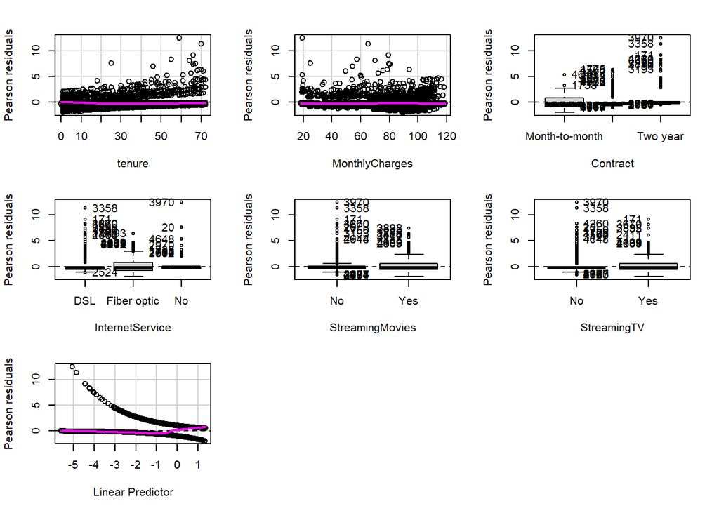

```
##                 Test stat Pr(>|Test stat|)
## tenure            50.3544        1.283e-12 ***
## MonthlyCharges     7.9167         0.004898 **
## Contract
## InternetService
## StreamingMovies
## StreamingTV
## ---
## Signif. codes:  0 '***' 0.001 '**' 0.01 '*' 0.05 '.' 0.1 ' ' 1
```

```
## [1] 50.35436
```

```r
residualPlots(mod7)[01]
```

*MonthlyCharges* has a high VIF. We’ll may need to add transformations or maybe discard this parameter. For now, we’ll keep the parameters that we have been adding.

#TechSupport

```r
mod8 <- glm(Churn ~ tenure + MonthlyCharges + Contract + InternetService + StreamingMovies + StreamingTV + TechSupport, data=train, family=binomial)
summary(mod8) #4208.3 better
```

```
##
## Call:
## glm(formula = Churn ~ tenure + MonthlyCharges + Contract + InternetService +
##     StreamingMovies + StreamingTV + TechSupport, family = binomial,
##     data = train)
##
## Coefficients:
##                             Estimate Std. Error z value Pr(>|z|)
## (Intercept)                 0.159090   0.238689   0.667 0.505081
## tenure                     -0.031943   0.002487 -12.843  < 2e-16 ***
## MonthlyCharges             -0.012766   0.005395  -2.366 0.017963 *
## ContractOne year           -0.840485   0.124232  -6.765 1.33e-11 ***
## ContractTwo year           -1.697874   0.210219  -8.077 6.66e-16 ***
## InternetServiceFiber optic  1.451761   0.197112   7.365 1.77e-13 ***
## InternetServiceNo          -1.320058   0.192969  -6.841 7.88e-12 ***
## StreamingMoviesYes          0.406906   0.106602   3.817 0.000135 ***
## StreamingTVYes              0.513242   0.108091   4.748 2.05e-06 ***
## TechSupportYes             -0.280916   0.104444  -2.690 0.007153 **
## ---
## Signif. codes:  0 '***' 0.001 '**' 0.01 '*' 0.05 '.' 0.1 ' ' 1
##
## (Dispersion parameter for binomial family taken to be 1)
##
##     Null deviance: 5694.2  on 4929  degrees of freedom
## Residual deviance: 4188.3  on 4920  degrees of freedom
## AIC: 4208.3
##
## Number of Fisher Scoring iterations: 6
```

```r
anova( mod7, mod8,  test="Chisq") #significant
```

```
## Analysis of Deviance Table
##
## Model 1: Churn ~ tenure + MonthlyCharges + Contract + InternetService +
##     StreamingMovies + StreamingTV
## Model 2: Churn ~ tenure + MonthlyCharges + Contract + InternetService +
##     StreamingMovies + StreamingTV + TechSupport
##   Resid. Df Resid. Dev Df Deviance Pr(>Chi)
## 1      4921     4195.5
## 2      4920     4188.3  1   7.2764 0.006987 **
## ---
## Signif. codes:  0 '***' 0.001 '**' 0.01 '*' 0.05 '.' 0.1 ' ' 1
```

```r
vif(mod8)
```

```
##                      GVIF Df GVIF^(1/(2*Df))
## tenure           1.732344  1        1.316185
## MonthlyCharges  13.838376  1        3.719997
## Contract         1.475851  2        1.102201
## InternetService  9.342986  2        1.748322
## StreamingMovies  1.893830  1        1.376165
## StreamingTV      1.943568  1        1.394119
## TechSupport      1.294163  1        1.137613
```

#DeviceProtection

```r
mod9 <- glm(Churn ~ tenure + MonthlyCharges + Contract + InternetService + StreamingMovies + StreamingTV + TechSupport + DeviceProtection, data=train, family=binomial)
summary(mod9) #4209.3 worse
```

```
##
## Call:
## glm(formula = Churn ~ tenure + MonthlyCharges + Contract + InternetService +
##     StreamingMovies + StreamingTV + TechSupport + DeviceProtection,
##     family = binomial, data = train)
##
## Coefficients:
##                            Estimate Std. Error z value Pr(>|z|)
## (Intercept)                 0.20725    0.24332   0.852 0.394345
## tenure                     -0.03217    0.00250 -12.868  < 2e-16 ***
## MonthlyCharges             -0.01417    0.00558  -2.539 0.011129 *
## ContractOne year           -0.84846    0.12453  -6.813 9.54e-12 ***
## ContractTwo year           -1.71130    0.21068  -8.123 4.55e-16 ***
## InternetServiceFiber optic  1.49636    0.20259   7.386 1.51e-13 ***
## InternetServiceNo          -1.33473    0.19328  -6.906 5.00e-12 ***
## StreamingMoviesYes          0.41040    0.10661   3.850 0.000118 ***
## StreamingTVYes              0.51843    0.10817   4.793 1.64e-06 ***
## TechSupportYes             -0.27817    0.10447  -2.663 0.007751 **
## DeviceProtectionYes         0.09141    0.09477   0.965 0.334789
## ---
## Signif. codes:  0 '***' 0.001 '**' 0.01 '*' 0.05 '.' 0.1 ' ' 1
##
## (Dispersion parameter for binomial family taken to be 1)
##
##     Null deviance: 5694.2  on 4929  degrees of freedom
## Residual deviance: 4187.3  on 4919  degrees of freedom
## AIC: 4209.3
##
## Number of Fisher Scoring iterations: 6
```

```r
anova( mod8, mod9,  test="Chisq") #not significant
```

```
## Analysis of Deviance Table
##
## Model 1: Churn ~ tenure + MonthlyCharges + Contract + InternetService +
##     StreamingMovies + StreamingTV + TechSupport
## Model 2: Churn ~ tenure + MonthlyCharges + Contract + InternetService +
##     StreamingMovies + StreamingTV + TechSupport + DeviceProtection
##   Resid. Df Resid. Dev Df Deviance Pr(>Chi)
## 1      4920     4188.3
## 2      4919     4187.3  1  0.93092   0.3346
```

We don’t add the parameter to the model. It does not improve it.

#OnlineBackup

```r
mod10 <- glm(Churn ~ tenure + MonthlyCharges + Contract + InternetService + StreamingMovies + StreamingTV + TechSupport + OnlineBackup, data=train, family=binomial)
summary(mod10) #4209.6 worse
```

```
##
## Call:
## glm(formula = Churn ~ tenure + MonthlyCharges + Contract + InternetService +
##     StreamingMovies + StreamingTV + TechSupport + OnlineBackup,
##     family = binomial, data = train)
##
## Coefficients:
##                             Estimate Std. Error z value Pr(>|z|)
## (Intercept)                 0.208031   0.246005   0.846   0.3978
## tenure                     -0.032365   0.002543 -12.725  < 2e-16 ***
## MonthlyCharges             -0.014254   0.005701  -2.500   0.0124 *
## ContractOne year           -0.840426   0.124233  -6.765 1.33e-11 ***
## ContractTwo year           -1.697207   0.210177  -8.075 6.74e-16 ***
## InternetServiceFiber optic  1.501499   0.206770   7.262 3.82e-13 ***
## InternetServiceNo          -1.333854   0.193546  -6.892 5.51e-12 ***
## StreamingMoviesYes          0.421961   0.108219   3.899 9.65e-05 ***
## StreamingTVYes              0.528477   0.109739   4.816 1.47e-06 ***
## TechSupportYes             -0.274417   0.104746  -2.620   0.0088 **
## OnlineBackupYes             0.075863   0.094753   0.801   0.4233
## ---
## Signif. codes:  0 '***' 0.001 '**' 0.01 '*' 0.05 '.' 0.1 ' ' 1
##
## (Dispersion parameter for binomial family taken to be 1)
##
##     Null deviance: 5694.2  on 4929  degrees of freedom
## Residual deviance: 4187.6  on 4919  degrees of freedom
## AIC: 4209.6
##
## Number of Fisher Scoring iterations: 6
```

```r
anova( mod8, mod10,  test="Chisq") #not significant
```

```
## Analysis of Deviance Table
##
## Model 1: Churn ~ tenure + MonthlyCharges + Contract + InternetService +
##     StreamingMovies + StreamingTV + TechSupport
## Model 2: Churn ~ tenure + MonthlyCharges + Contract + InternetService +
##     StreamingMovies + StreamingTV + TechSupport + OnlineBackup
##   Resid. Df Resid. Dev Df Deviance Pr(>Chi)
## 1      4920     4188.3
## 2      4919     4187.6  1  0.64158   0.4231
```

We don’t add the parameter to the model. It does not improve it.

#OnlineSecurity

```r
mod11 <- glm(Churn ~ tenure + MonthlyCharges + Contract + InternetService + StreamingMovies + StreamingTV + TechSupport + OnlineSecurity, data=train, family=binomial)
summary(mod11) #4199 better
```

```
##
## Call:
## glm(formula = Churn ~ tenure + MonthlyCharges + Contract + InternetService +
##     StreamingMovies + StreamingTV + TechSupport + OnlineSecurity,
##     family = binomial, data = train)
##
## Coefficients:
##                             Estimate Std. Error z value Pr(>|z|)
## (Intercept)                -0.008236   0.246066  -0.033 0.973301
## tenure                     -0.031275   0.002499 -12.517  < 2e-16 ***
## MonthlyCharges             -0.006781   0.005721  -1.185 0.235905
## ContractOne year           -0.811442   0.124827  -6.501 8.00e-11 ***
## ContractTwo year           -1.641703   0.211038  -7.779 7.30e-15 ***
## InternetServiceFiber optic  1.204840   0.210706   5.718 1.08e-08 ***
## InternetServiceNo          -1.292005   0.194222  -6.652 2.89e-11 ***
## StreamingMoviesYes          0.339293   0.108944   3.114 0.001843 **
## StreamingTVYes              0.440566   0.110618   3.983 6.81e-05 ***
## TechSupportYes             -0.292683   0.104734  -2.795 0.005197 **
## OnlineSecurityYes          -0.352840   0.105394  -3.348 0.000815 ***
## ---
## Signif. codes:  0 '***' 0.001 '**' 0.01 '*' 0.05 '.' 0.1 ' ' 1
##
## (Dispersion parameter for binomial family taken to be 1)
##
##     Null deviance: 5694.2  on 4929  degrees of freedom
## Residual deviance: 4177.0  on 4919  degrees of freedom
## AIC: 4199
##
## Number of Fisher Scoring iterations: 6
```

```r
anova( mod8, mod11,  test="Chisq") #significant
```

```
## Analysis of Deviance Table
##
## Model 1: Churn ~ tenure + MonthlyCharges + Contract + InternetService +
##     StreamingMovies + StreamingTV + TechSupport
## Model 2: Churn ~ tenure + MonthlyCharges + Contract + InternetService +
##     StreamingMovies + StreamingTV + TechSupport + OnlineSecurity
##   Resid. Df Resid. Dev Df Deviance  Pr(>Chi)
## 1      4920     4188.3
## 2      4919     4177.0  1   11.321 0.0007665 ***
## ---
## Signif. codes:  0 '***' 0.001 '**' 0.01 '*' 0.05 '.' 0.1 ' ' 1
```

```r
vif(mod11)
```

```
##                      GVIF Df GVIF^(1/(2*Df))
## tenure           1.744624  1        1.320842
## MonthlyCharges  15.487373  1        3.935400
## Contract         1.492903  2        1.105371
## InternetService 10.866851  2        1.815624
## StreamingMovies  1.971177  1        1.403986
## StreamingTV      2.028530  1        1.424265
## TechSupport      1.296059  1        1.138446
## OnlineSecurity   1.242751  1        1.114787
```

```r
#residualPlot(mod11)
```

We keep the parameter

#PaperlessBilling

```r
mod12 <- glm(Churn ~ tenure + MonthlyCharges + Contract + InternetService + StreamingMovies + StreamingTV + TechSupport + OnlineSecurity + PaperlessBilling, data=train, family=binomial)
summary(mod12) #4184.5 better
```

```
##
## Call:
## glm(formula = Churn ~ tenure + MonthlyCharges + Contract + InternetService +
##     StreamingMovies + StreamingTV + TechSupport + OnlineSecurity +
##     PaperlessBilling, family = binomial, data = train)
##
## Coefficients:
##                             Estimate Std. Error z value Pr(>|z|)
## (Intercept)                -0.206715   0.251517  -0.822 0.411150
## tenure                     -0.031980   0.002512 -12.730  < 2e-16 ***
## MonthlyCharges             -0.006893   0.005737  -1.202 0.229554
## ContractOne year           -0.774511   0.125366  -6.178 6.49e-10 ***
## ContractTwo year           -1.575801   0.211901  -7.436 1.03e-13 ***
## InternetServiceFiber optic  1.162390   0.211629   5.493 3.96e-08 ***
## InternetServiceNo          -1.216241   0.195326  -6.227 4.76e-10 ***
## StreamingMoviesYes          0.328093   0.109142   3.006 0.002646 **
## StreamingTVYes              0.412453   0.111023   3.715 0.000203 ***
## TechSupportYes             -0.293252   0.105072  -2.791 0.005255 **
## OnlineSecurityYes          -0.325252   0.105781  -3.075 0.002107 **
## PaperlessBillingYes         0.354796   0.087670   4.047 5.19e-05 ***
## ---
## Signif. codes:  0 '***' 0.001 '**' 0.01 '*' 0.05 '.' 0.1 ' ' 1
##
## (Dispersion parameter for binomial family taken to be 1)
##
##     Null deviance: 5694.2  on 4929  degrees of freedom
## Residual deviance: 4160.5  on 4918  degrees of freedom
## AIC: 4184.5
##
## Number of Fisher Scoring iterations: 6
```

```r
anova( mod11, mod12,  test="Chisq") #significant
```

```
## Analysis of Deviance Table
##
## Model 1: Churn ~ tenure + MonthlyCharges + Contract + InternetService +
##     StreamingMovies + StreamingTV + TechSupport + OnlineSecurity
## Model 2: Churn ~ tenure + MonthlyCharges + Contract + InternetService +
##     StreamingMovies + StreamingTV + TechSupport + OnlineSecurity +
##     PaperlessBilling
##   Resid. Df Resid. Dev Df Deviance  Pr(>Chi)
## 1      4919     4177.0
## 2      4918     4160.5  1   16.478 4.923e-05 ***
## ---
## Signif. codes:  0 '***' 0.001 '**' 0.01 '*' 0.05 '.' 0.1 ' ' 1
```

```r
vif(mod12)
```

```
##                       GVIF Df GVIF^(1/(2*Df))
## tenure            1.760119  1        1.326695
## MonthlyCharges   15.519259  1        3.939449
## Contract          1.507661  2        1.108092
## InternetService  10.973792  2        1.820075
## StreamingMovies   1.970408  1        1.403712
## StreamingTV       2.035605  1        1.426746
## TechSupport       1.298079  1        1.139333
## OnlineSecurity    1.247294  1        1.116823
## PaperlessBilling  1.111928  1        1.054480
```

We keep the parameter

#Dependents

```r
mod13 <- glm(Churn ~ tenure + MonthlyCharges + Contract + InternetService + StreamingMovies + StreamingTV + TechSupport + OnlineSecurity + PaperlessBilling + Dependents, data=train, family=binomial)
summary(mod13) #4177.2 better
```

```
##
## Call:
## glm(formula = Churn ~ tenure + MonthlyCharges + Contract + InternetService +
##     StreamingMovies + StreamingTV + TechSupport + OnlineSecurity +
##     PaperlessBilling + Dependents, family = binomial, data = train)
##
## Coefficients:
##                             Estimate Std. Error z value Pr(>|z|)
## (Intercept)                -0.160331   0.252462  -0.635  0.52538
## tenure                     -0.031654   0.002520 -12.559  < 2e-16 ***
## MonthlyCharges             -0.006595   0.005749  -1.147  0.25137
## ContractOne year           -0.746604   0.125870  -5.932 3.00e-09 ***
## ContractTwo year           -1.536143   0.212595  -7.226 4.99e-13 ***
## InternetServiceFiber optic  1.133942   0.212173   5.344 9.07e-08 ***
## InternetServiceNo          -1.193933   0.195766  -6.099 1.07e-09 ***
## StreamingMoviesYes          0.317729   0.109348   2.906  0.00366 **
## StreamingTVYes              0.412210   0.111213   3.706  0.00021 ***
## TechSupportYes             -0.287327   0.105193  -2.731  0.00631 **
## OnlineSecurityYes          -0.317077   0.105920  -2.994  0.00276 **
## PaperlessBillingYes         0.351625   0.087803   4.005 6.21e-05 ***
## DependentsYes              -0.291003   0.096298  -3.022  0.00251 **
## ---
## Signif. codes:  0 '***' 0.001 '**' 0.01 '*' 0.05 '.' 0.1 ' ' 1
##
## (Dispersion parameter for binomial family taken to be 1)
##
##     Null deviance: 5694.2  on 4929  degrees of freedom
## Residual deviance: 4151.2  on 4917  degrees of freedom
## AIC: 4177.2
##
## Number of Fisher Scoring iterations: 6
```

```r
anova( mod12, mod13,  test="Chisq") #significant
```

```
## Analysis of Deviance Table
##
## Model 1: Churn ~ tenure + MonthlyCharges + Contract + InternetService +
##     StreamingMovies + StreamingTV + TechSupport + OnlineSecurity +
##     PaperlessBilling
## Model 2: Churn ~ tenure + MonthlyCharges + Contract + InternetService +
##     StreamingMovies + StreamingTV + TechSupport + OnlineSecurity +
##     PaperlessBilling + Dependents
##   Resid. Df Resid. Dev Df Deviance Pr(>Chi)
## 1      4918     4160.5
## 2      4917     4151.2  1   9.2692  0.00233 **
## ---
## Signif. codes:  0 '***' 0.001 '**' 0.01 '*' 0.05 '.' 0.1 ' ' 1
```

```r
vif(mod13)
```

```
##                       GVIF Df GVIF^(1/(2*Df))
## tenure            1.773404  1        1.331692
## MonthlyCharges   15.562560  1        3.944941
## Contract          1.522708  2        1.110847
## InternetService  10.992492  2        1.820849
## StreamingMovies   1.973305  1        1.404744
## StreamingTV       2.037770  1        1.427505
## TechSupport       1.299374  1        1.139901
## OnlineSecurity    1.247956  1        1.117120
## PaperlessBilling  1.112626  1        1.054811
## Dependents        1.027601  1        1.013706
```

We keep the parameter

#MultipleLines

```r
mod14 <- glm(Churn ~ tenure + MonthlyCharges + Contract + InternetService + StreamingMovies + StreamingTV + TechSupport + OnlineSecurity + PaperlessBilling + Dependents + MultipleLines, data=train, family=binomial)
summary(mod14) #4162.2 better
```

```
##
## Call:
## glm(formula = Churn ~ tenure + MonthlyCharges + Contract + InternetService +
##     StreamingMovies + StreamingTV + TechSupport + OnlineSecurity +
##     PaperlessBilling + Dependents + MultipleLines, family = binomial,
##     data = train)
##
## Coefficients:
##                             Estimate Std. Error z value Pr(>|z|)
## (Intercept)                 0.325614   0.276930   1.176 0.239675
## tenure                     -0.033818   0.002590 -13.059  < 2e-16 ***
## MonthlyCharges             -0.019128   0.006487  -2.949 0.003190 **
## ContractOne year           -0.708250   0.126272  -5.609 2.04e-08 ***
## ContractTwo year           -1.505396   0.212577  -7.082 1.42e-12 ***
## InternetServiceFiber optic  1.425577   0.223890   6.367 1.92e-10 ***
## InternetServiceNo          -1.452191   0.204587  -7.098 1.26e-12 ***
## StreamingMoviesYes          0.434506   0.113253   3.837 0.000125 ***
## StreamingTVYes              0.522217   0.114574   4.558 5.17e-06 ***
## TechSupportYes             -0.201538   0.107221  -1.880 0.060155 .
## OnlineSecurityYes          -0.241060   0.107617  -2.240 0.025093 *
## PaperlessBillingYes         0.337471   0.087923   3.838 0.000124 ***
## DependentsYes              -0.283338   0.096401  -2.939 0.003291 **
## MultipleLinesYes            0.422899   0.102860   4.111 3.93e-05 ***
## ---
## Signif. codes:  0 '***' 0.001 '**' 0.01 '*' 0.05 '.' 0.1 ' ' 1
##
## (Dispersion parameter for binomial family taken to be 1)
##
##     Null deviance: 5694.2  on 4929  degrees of freedom
## Residual deviance: 4134.2  on 4916  degrees of freedom
## AIC: 4162.2
##
## Number of Fisher Scoring iterations: 6
```

```r
anova( mod13, mod14,  test="Chisq") #significant
```

```
## Analysis of Deviance Table
##
## Model 1: Churn ~ tenure + MonthlyCharges + Contract + InternetService +
##     StreamingMovies + StreamingTV + TechSupport + OnlineSecurity +
##     PaperlessBilling + Dependents
## Model 2: Churn ~ tenure + MonthlyCharges + Contract + InternetService +
##     StreamingMovies + StreamingTV + TechSupport + OnlineSecurity +
##     PaperlessBilling + Dependents + MultipleLines
##   Resid. Df Resid. Dev Df Deviance  Pr(>Chi)
## 1      4917     4151.2
## 2      4916     4134.2  1   17.026 3.688e-05 ***
## ---
## Signif. codes:  0 '***' 0.001 '**' 0.01 '*' 0.05 '.' 0.1 ' ' 1
```

```r
vif(mod14)
```

```
##                       GVIF Df GVIF^(1/(2*Df))
## tenure            1.860860  1        1.364133
## MonthlyCharges   19.785122  1        4.448047
## Contract          1.529039  2        1.112000
## InternetService  12.562934  2        1.882664
## StreamingMovies   2.104685  1        1.450753
## StreamingTV       2.150829  1        1.466570
## TechSupport       1.346109  1        1.160219
## OnlineSecurity    1.283323  1        1.132838
## PaperlessBilling  1.113149  1        1.055059
## Dependents        1.028391  1        1.014096
## MultipleLines     1.749163  1        1.322559
```

We keep the parameter

#SeniorCitizen

```r
mod15 <- glm(Churn ~ tenure + MonthlyCharges + Contract + InternetService + StreamingMovies + StreamingTV + TechSupport + OnlineSecurity + PaperlessBilling + Dependents + MultipleLines + SeniorCitizen, data=train, family=binomial)
summary(mod15) #4155.7 better
```

```
##
## Call:
## glm(formula = Churn ~ tenure + MonthlyCharges + Contract + InternetService +
##     StreamingMovies + StreamingTV + TechSupport + OnlineSecurity +
##     PaperlessBilling + Dependents + MultipleLines + SeniorCitizen,
##     family = binomial, data = train)
##
## Coefficients:
##                             Estimate Std. Error z value Pr(>|z|)
## (Intercept)                 0.267247   0.277985   0.961 0.336364
## tenure                     -0.034666   0.002614 -13.260  < 2e-16 ***
## MonthlyCharges             -0.018721   0.006495  -2.883 0.003945 **
## ContractOne year           -0.687576   0.126551  -5.433 5.54e-08 ***
## ContractTwo year           -1.471829   0.212912  -6.913 4.75e-12 ***
## InternetServiceFiber optic  1.389895   0.224330   6.196 5.80e-10 ***
## InternetServiceNo          -1.414902   0.205187  -6.896 5.36e-12 ***
## StreamingMoviesYes          0.427058   0.113402   3.766 0.000166 ***
## StreamingTVYes              0.515559   0.114692   4.495 6.95e-06 ***
## TechSupportYes             -0.180640   0.107602  -1.679 0.093196 .
## OnlineSecurityYes          -0.227662   0.107759  -2.113 0.034627 *
## PaperlessBillingYes         0.330204   0.088016   3.752 0.000176 ***
## DependentsYes              -0.237905   0.097654  -2.436 0.014842 *
## MultipleLinesYes            0.409515   0.103119   3.971 7.15e-05 ***
## SeniorCitizen1              0.289328   0.099257   2.915 0.003558 **
## ---
## Signif. codes:  0 '***' 0.001 '**' 0.01 '*' 0.05 '.' 0.1 ' ' 1
##
## (Dispersion parameter for binomial family taken to be 1)
##
##     Null deviance: 5694.2  on 4929  degrees of freedom
## Residual deviance: 4125.7  on 4915  degrees of freedom
## AIC: 4155.7
##
## Number of Fisher Scoring iterations: 6
```

```r
anova( mod14, mod15,  test="Chisq") #significant
```

```
## Analysis of Deviance Table
##
## Model 1: Churn ~ tenure + MonthlyCharges + Contract + InternetService +
##     StreamingMovies + StreamingTV + TechSupport + OnlineSecurity +
##     PaperlessBilling + Dependents + MultipleLines
## Model 2: Churn ~ tenure + MonthlyCharges + Contract + InternetService +
##     StreamingMovies + StreamingTV + TechSupport + OnlineSecurity +
##     PaperlessBilling + Dependents + MultipleLines + SeniorCitizen
##   Resid. Df Resid. Dev Df Deviance Pr(>Chi)
## 1      4916     4134.2
## 2      4915     4125.7  1   8.4782 0.003594 **
## ---
## Signif. codes:  0 '***' 0.001 '**' 0.01 '*' 0.05 '.' 0.1 ' ' 1
```

```r
vif(mod15)
```

```
##                       GVIF Df GVIF^(1/(2*Df))
## tenure            1.889241  1        1.374497
## MonthlyCharges   19.790331  1        4.448632
## Contract          1.536772  2        1.113403
## InternetService  12.635139  2        1.885363
## StreamingMovies   2.104216  1        1.450592
## StreamingTV       2.148543  1        1.465791
## TechSupport       1.353673  1        1.163474
## OnlineSecurity    1.286526  1        1.134251
## PaperlessBilling  1.114284  1        1.055597
## Dependents        1.056349  1        1.027789
## MultipleLines     1.752169  1        1.323695
## SeniorCitizen     1.113813  1        1.055374
```

We keep the parameter

#Partner

```r
mod16 <- glm(Churn ~ tenure + MonthlyCharges + Contract + InternetService + StreamingMovies + StreamingTV + TechSupport + OnlineSecurity + PaperlessBilling + Dependents + MultipleLines + SeniorCitizen + Partner, data=train, family=binomial)
summary(mod16) #4157.7 worse
```

```
##
## Call:
## glm(formula = Churn ~ tenure + MonthlyCharges + Contract + InternetService +
##     StreamingMovies + StreamingTV + TechSupport + OnlineSecurity +
##     PaperlessBilling + Dependents + MultipleLines + SeniorCitizen +
##     Partner, family = binomial, data = train)
##
## Coefficients:
##                             Estimate Std. Error z value Pr(>|z|)
## (Intercept)                 0.265985   0.278118   0.956 0.338882
## tenure                     -0.034758   0.002679 -12.975  < 2e-16 ***
## MonthlyCharges             -0.018728   0.006495  -2.883 0.003934 **
## ContractOne year           -0.687576   0.126545  -5.433 5.53e-08 ***
## ContractTwo year           -1.471574   0.212916  -6.912 4.79e-12 ***
## InternetServiceFiber optic  1.389752   0.224333   6.195 5.83e-10 ***
## InternetServiceNo          -1.414725   0.205201  -6.894 5.41e-12 ***
## StreamingMoviesYes          0.426914   0.113407   3.764 0.000167 ***
## StreamingTVYes              0.515289   0.114703   4.492 7.04e-06 ***
## TechSupportYes             -0.180477   0.107609  -1.677 0.093512 .
## OnlineSecurityYes          -0.227837   0.107764  -2.114 0.034496 *
## PaperlessBillingYes         0.330424   0.088026   3.754 0.000174 ***
## DependentsYes              -0.244710   0.106734  -2.293 0.021864 *
## MultipleLinesYes            0.409511   0.103119   3.971 7.15e-05 ***
## SeniorCitizen1              0.287578   0.099871   2.880 0.003983 **
## PartnerYes                  0.014465   0.091544   0.158 0.874447
## ---
## Signif. codes:  0 '***' 0.001 '**' 0.01 '*' 0.05 '.' 0.1 ' ' 1
##
## (Dispersion parameter for binomial family taken to be 1)
##
##     Null deviance: 5694.2  on 4929  degrees of freedom
## Residual deviance: 4125.7  on 4914  degrees of freedom
## AIC: 4157.7
##
## Number of Fisher Scoring iterations: 6
```

```r
anova( mod15, mod16,  test="Chisq") #not significant
```

```
## Analysis of Deviance Table
##
## Model 1: Churn ~ tenure + MonthlyCharges + Contract + InternetService +
##     StreamingMovies + StreamingTV + TechSupport + OnlineSecurity +
##     PaperlessBilling + Dependents + MultipleLines + SeniorCitizen
## Model 2: Churn ~ tenure + MonthlyCharges + Contract + InternetService +
##     StreamingMovies + StreamingTV + TechSupport + OnlineSecurity +
##     PaperlessBilling + Dependents + MultipleLines + SeniorCitizen +
##     Partner
##   Resid. Df Resid. Dev Df Deviance Pr(>Chi)
## 1      4915     4125.7
## 2      4914     4125.7  1 0.024971   0.8744
```

We don’t keep the parameter

#PaymentMethod

```r
mod17 <- glm(Churn ~ tenure + MonthlyCharges + Contract + InternetService + StreamingMovies + StreamingTV + TechSupport + OnlineSecurity + PaperlessBilling + Dependents + MultipleLines + SeniorCitizen + PaymentMethod, data=train, family=binomial)
summary(mod17) #4139.4 better
```

```
##
## Call:
## glm(formula = Churn ~ tenure + MonthlyCharges + Contract + InternetService +
##     StreamingMovies + StreamingTV + TechSupport + OnlineSecurity +
##     PaperlessBilling + Dependents + MultipleLines + SeniorCitizen +
##     PaymentMethod, family = binomial, data = train)
##
## Coefficients:
##                                       Estimate Std. Error z value Pr(>|z|)
## (Intercept)                           0.070752   0.297751   0.238 0.812174
## tenure                               -0.033270   0.002671 -12.454  < 2e-16 ***
## MonthlyCharges                       -0.017433   0.006529  -2.670 0.007580 **
## ContractOne year                     -0.660779   0.126880  -5.208 1.91e-07 ***
## ContractTwo year                     -1.426923   0.213449  -6.685 2.31e-11 ***
## InternetServiceFiber optic            1.293245   0.226310   5.714 1.10e-08 ***
## InternetServiceNo                    -1.304750   0.208471  -6.259 3.88e-10 ***
## StreamingMoviesYes                    0.395594   0.113994   3.470 0.000520 ***
## StreamingTVYes                        0.472452   0.115512   4.090 4.31e-05 ***
## TechSupportYes                       -0.157729   0.108022  -1.460 0.144247
## OnlineSecurityYes                    -0.208169   0.108243  -1.923 0.054459 .
## PaperlessBillingYes                   0.310428   0.088576   3.505 0.000457 ***
## DependentsYes                        -0.224946   0.097913  -2.297 0.021595 *
## MultipleLinesYes                      0.396569   0.103521   3.831 0.000128 ***
## SeniorCitizen1                        0.264339   0.099866   2.647 0.008122 **
## PaymentMethodCredit card (automatic) -0.078607   0.135723  -0.579 0.562473
## PaymentMethodElectronic check         0.364430   0.113262   3.218 0.001293 **
## PaymentMethodMailed check             0.011420   0.136200   0.084 0.933179
## ---
## Signif. codes:  0 '***' 0.001 '**' 0.01 '*' 0.05 '.' 0.1 ' ' 1
##
## (Dispersion parameter for binomial family taken to be 1)
##
##     Null deviance: 5694.2  on 4929  degrees of freedom
## Residual deviance: 4103.4  on 4912  degrees of freedom
## AIC: 4139.4
##
## Number of Fisher Scoring iterations: 6
```

```r
anova( mod15, mod17,  test="Chisq") #significant
```

```
## Analysis of Deviance Table
##
## Model 1: Churn ~ tenure + MonthlyCharges + Contract + InternetService +
##     StreamingMovies + StreamingTV + TechSupport + OnlineSecurity +
##     PaperlessBilling + Dependents + MultipleLines + SeniorCitizen
## Model 2: Churn ~ tenure + MonthlyCharges + Contract + InternetService +
##     StreamingMovies + StreamingTV + TechSupport + OnlineSecurity +
##     PaperlessBilling + Dependents + MultipleLines + SeniorCitizen +
##     PaymentMethod
##   Resid. Df Resid. Dev Df Deviance  Pr(>Chi)
## 1      4915     4125.7
## 2      4912     4103.4  3   22.269 5.735e-05 ***
## ---
## Signif. codes:  0 '***' 0.001 '**' 0.01 '*' 0.05 '.' 0.1 ' ' 1
```

```r
vif(mod17)
```

```
##                       GVIF Df GVIF^(1/(2*Df))
## tenure            1.963626  1        1.401295
## MonthlyCharges   19.895259  1        4.460410
## Contract          1.543913  2        1.114694
## InternetService  13.046889  2        1.900539
## StreamingMovies   2.110866  1        1.452882
## StreamingTV       2.164001  1        1.471054
## TechSupport       1.357356  1        1.165056
## OnlineSecurity    1.291867  1        1.136603
## PaperlessBilling  1.120742  1        1.058651
## Dependents        1.057502  1        1.028349
## MultipleLines     1.753352  1        1.324142
## SeniorCitizen     1.116591  1        1.056689
## PaymentMethod     1.332467  3        1.049001
```

#PhoneService

```r
mod18 <- glm(Churn ~ tenure + MonthlyCharges + Contract + InternetService + StreamingMovies + StreamingTV + TechSupport + OnlineSecurity + PaperlessBilling + Dependents + MultipleLines + SeniorCitizen + PaymentMethod + PhoneService, data=train, family=binomial)
summary(mod18) #4139.4 it does not change anything
```

```
##
## Call:
## glm(formula = Churn ~ tenure + MonthlyCharges + Contract + InternetService +
##     StreamingMovies + StreamingTV + TechSupport + OnlineSecurity +
##     PaperlessBilling + Dependents + MultipleLines + SeniorCitizen +
##     PaymentMethod + PhoneService, family = binomial, data = train)
##
## Coefficients:
##                                       Estimate Std. Error z value Pr(>|z|)
## (Intercept)                          -0.237709   0.366847  -0.648 0.516998
## tenure                               -0.034292   0.002768 -12.387  < 2e-16 ***
## MonthlyCharges                       -0.002716   0.012162  -0.223 0.823319
## ContractOne year                     -0.666781   0.126959  -5.252 1.51e-07 ***
## ContractTwo year                     -1.438924   0.213552  -6.738 1.61e-11 ***
## InternetServiceFiber optic            0.961078   0.323676   2.969 0.002985 **
## InternetServiceNo                    -0.865765   0.370693  -2.336 0.019516 *
## StreamingMoviesYes                    0.236356   0.158998   1.487 0.137138
## StreamingTVYes                        0.316047   0.158725   1.991 0.046463 *
## TechSupportYes                       -0.234653   0.120629  -1.945 0.051744 .
## OnlineSecurityYes                    -0.275385   0.118024  -2.333 0.019632 *
## PaperlessBillingYes                   0.308580   0.088640   3.481 0.000499 ***
## DependentsYes                        -0.224714   0.097926  -2.295 0.021748 *
## MultipleLinesYes                      0.336720   0.111645   3.016 0.002561 **
## SeniorCitizen1                        0.259295   0.099923   2.595 0.009460 **
## PaymentMethodCredit card (automatic) -0.085694   0.135867  -0.631 0.528222
## PaymentMethodElectronic check         0.362532   0.113278   3.200 0.001373 **
## PaymentMethodMailed check             0.008268   0.136324   0.061 0.951640
## PhoneServiceYes                      -0.408196   0.284634  -1.434 0.151542
## ---
## Signif. codes:  0 '***' 0.001 '**' 0.01 '*' 0.05 '.' 0.1 ' ' 1
##
## (Dispersion parameter for binomial family taken to be 1)
##
##     Null deviance: 5694.2  on 4929  degrees of freedom
## Residual deviance: 4101.4  on 4911  degrees of freedom
## AIC: 4139.4
##
## Number of Fisher Scoring iterations: 6
```

```r
anova( mod17, mod18,  test="Chisq") #not significant
```

```
## Analysis of Deviance Table
##
## Model 1: Churn ~ tenure + MonthlyCharges + Contract + InternetService +
##     StreamingMovies + StreamingTV + TechSupport + OnlineSecurity +
##     PaperlessBilling + Dependents + MultipleLines + SeniorCitizen +
##     PaymentMethod
## Model 2: Churn ~ tenure + MonthlyCharges + Contract + InternetService +
##     StreamingMovies + StreamingTV + TechSupport + OnlineSecurity +
##     PaperlessBilling + Dependents + MultipleLines + SeniorCitizen +
##     PaymentMethod + PhoneService
##   Resid. Df Resid. Dev Df Deviance Pr(>Chi)
## 1      4912     4103.4
## 2      4911     4101.4  1    2.055   0.1517
```

##Interactions

```r
str(train)
```

```
## 'data.frame':    4930 obs. of  21 variables:
##  $ customerID      : chr  "8917-FAEMR" "4851-BQDNX" "5445-GLVOT" "4750-ZRXIU" ...
##  $ gender          : Factor w/ 2 levels "Female","Male": 1 2 1 1 1 2 2 2 2 1 ...
##  $ SeniorCitizen   : Factor w/ 2 levels "0","1": 1 1 1 2 1 1 1 1 1 1 ...
##  $ Partner         : Factor w/ 2 levels "No","Yes": 1 2 1 1 1 2 1 2 2 1 ...
##  $ Dependents      : Factor w/ 2 levels "No","Yes": 1 2 1 1 1 2 1 1 1 1 ...
##  $ tenure          : int  37 40 22 4 1 49 11 58 24 27 ...
##  $ PhoneService    : Factor w/ 2 levels "No","Yes": 2 2 2 2 2 2 2 1 1 2 ...
##  $ MultipleLines   : Factor w/ 3 levels "No","No phone service",..: 1 1 1 3 1 1 1 1 1 1 ...
##  $ InternetService : Factor w/ 3 levels "DSL","Fiber optic",..: 3 2 1 2 2 2 2 1 1 1 ...
##  $ OnlineSecurity  : Factor w/ 3 levels "No","No internet service",..: 1 1 3 1 1 1 1 1 1 3 ...
##  $ OnlineBackup    : Factor w/ 3 levels "No","No internet service",..: 1 1 1 1 1 3 1 1 1 3 ...
##  $ DeviceProtection: Factor w/ 3 levels "No","No internet service",..: 1 3 1 1 1 3 3 1 3 1 ...
##  $ TechSupport     : Factor w/ 3 levels "No","No internet service",..: 1 1 1 1 1 1 1 1 1 1 ...
##  $ StreamingTV     : Factor w/ 3 levels "No","No internet service",..: 1 3 1 1 1 3 1 3 1 1 ...
##  $ StreamingMovies : Factor w/ 3 levels "No","No internet service",..: 1 1 1 3 1 1 1 3 1 1 ...
##  $ Contract        : Factor w/ 3 levels "Month-to-month",..: 3 2 1 1 1 1 1 2 1 3 ...
##  $ PaperlessBilling: Factor w/ 2 levels "No","Yes": 1 2 2 2 2 2 1 2 1 1 ...
##  $ PaymentMethod   : Factor w/ 4 levels "Bank transfer (automatic)",..: 4 3 3 3 3 2 3 2 3 1 ...
##  $ MonthlyCharges  : num  19.9 85 49.8 84.6 70.1 ...
##  $ TotalCharges    : num  784.2 3355.7 1049 360.1 70.1 ...
##  $ Churn           : Factor w/ 2 levels "No","Yes": 1 1 1 2 2 1 1 1 1 1 ...
```

We need to search for interactions. Possible interactions:

- Dependents and Multiple Lines

```r
mod19 <- glm(Churn ~ tenure + MonthlyCharges + Contract + InternetService + StreamingMovies + StreamingTV + TechSupport + OnlineSecurity + PaperlessBilling + Dependents * MultipleLines + SeniorCitizen + PaymentMethod, data=train, family=binomial)
summary(mod19) #4140.4 worse
```

```
##
## Call:
## glm(formula = Churn ~ tenure + MonthlyCharges + Contract + InternetService +
##     StreamingMovies + StreamingTV + TechSupport + OnlineSecurity +
##     PaperlessBilling + Dependents * MultipleLines + SeniorCitizen +
##     PaymentMethod, family = binomial, data = train)
##
## Coefficients:
##                                       Estimate Std. Error z value Pr(>|z|)
## (Intercept)                           0.052152   0.298076   0.175 0.861108
## tenure                               -0.033288   0.002673 -12.452  < 2e-16 ***
## MonthlyCharges                       -0.017353   0.006523  -2.660 0.007805 **
## ContractOne year                     -0.660307   0.126854  -5.205 1.94e-07 ***
## ContractTwo year                     -1.425823   0.213425  -6.681 2.38e-11 ***
## InternetServiceFiber optic            1.290777   0.226253   5.705 1.16e-08 ***
## InternetServiceNo                    -1.304431   0.208303  -6.262 3.80e-10 ***
## StreamingMoviesYes                    0.395038   0.113980   3.466 0.000529 ***
## StreamingTVYes                        0.471360   0.115511   4.081 4.49e-05 ***
## TechSupportYes                       -0.155875   0.108038  -1.443 0.149084
## OnlineSecurityYes                    -0.210440   0.108257  -1.944 0.051909 .
## PaperlessBillingYes                   0.310985   0.088566   3.511 0.000446 ***
## DependentsYes                        -0.143040   0.125091  -1.143 0.252835
## MultipleLinesYes                      0.437597   0.110848   3.948 7.89e-05 ***
## SeniorCitizen1                        0.260630   0.099962   2.607 0.009126 **
## PaymentMethodCredit card (automatic) -0.079231   0.135761  -0.584 0.559483
## PaymentMethodElectronic check         0.361969   0.113331   3.194 0.001404 **
## PaymentMethodMailed check             0.009198   0.136248   0.068 0.946176
## DependentsYes:MultipleLinesYes       -0.201472   0.194277  -1.037 0.299720
## ---
## Signif. codes:  0 '***' 0.001 '**' 0.01 '*' 0.05 '.' 0.1 ' ' 1
##
## (Dispersion parameter for binomial family taken to be 1)
##
##     Null deviance: 5694.2  on 4929  degrees of freedom
## Residual deviance: 4102.4  on 4911  degrees of freedom
## AIC: 4140.4
##
## Number of Fisher Scoring iterations: 6
```

```r
anova( mod17, mod19,  test="Chisq") #not significant
```

```
## Analysis of Deviance Table
##
## Model 1: Churn ~ tenure + MonthlyCharges + Contract + InternetService +
##     StreamingMovies + StreamingTV + TechSupport + OnlineSecurity +
##     PaperlessBilling + Dependents + MultipleLines + SeniorCitizen +
##     PaymentMethod
## Model 2: Churn ~ tenure + MonthlyCharges + Contract + InternetService +
##     StreamingMovies + StreamingTV + TechSupport + OnlineSecurity +
##     PaperlessBilling + Dependents * MultipleLines + SeniorCitizen +
##     PaymentMethod
##   Resid. Df Resid. Dev Df Deviance Pr(>Chi)
## 1      4912     4103.4
## 2      4911     4102.4  1   1.0787    0.299
```

```r
vif(mod19)
```

```
## there are higher-order terms (interactions) in this model
## consider setting type = 'predictor'; see ?vif
```

```
##                               GVIF Df GVIF^(1/(2*Df))
## tenure                    1.963652  1        1.401304
## MonthlyCharges           19.861675  1        4.456644
## Contract                  1.542611  2        1.114459
## InternetService          13.037734  2        1.900205
## StreamingMovies           2.108868  1        1.452194
## StreamingTV               2.162588  1        1.470574
## TechSupport               1.357407  1        1.165078
## OnlineSecurity            1.291919  1        1.136626
## PaperlessBilling          1.120772  1        1.058665
## Dependents                1.727871  1        1.314485
## MultipleLines             2.006866  1        1.416639
## SeniorCitizen             1.117955  1        1.057334
## PaymentMethod             1.333165  3        1.049093
## Dependents:MultipleLines  1.920303  1        1.385750
```

- MonthlyCharges and InternetService

```r
mod20 <- glm(Churn ~ tenure + InternetService * MonthlyCharges + Contract + StreamingMovies + StreamingTV + TechSupport + OnlineSecurity + PaperlessBilling + Dependents + MultipleLines + SeniorCitizen + PaymentMethod, data=train, family=binomial)
summary(mod20) #4133.7 better
```

```
##
## Call:
## glm(formula = Churn ~ tenure + InternetService * MonthlyCharges +
##     Contract + StreamingMovies + StreamingTV + TechSupport +
##     OnlineSecurity + PaperlessBilling + Dependents + MultipleLines +
##     SeniorCitizen + PaymentMethod, family = binomial, data = train)
##
## Coefficients:
##                                            Estimate Std. Error z value Pr(>|z|)
## (Intercept)                                0.375126   0.321672   1.166 0.243544
## tenure                                    -0.034642   0.002743 -12.631  < 2e-16
## InternetServiceFiber optic                -0.077307   0.611334  -0.126 0.899370
## InternetServiceNo                          1.574632   1.837650   0.857 0.391515
## MonthlyCharges                            -0.021382   0.006719  -3.182 0.001460
## ContractOne year                          -0.646656   0.127352  -5.078 3.82e-07
## ContractTwo year                          -1.374625   0.214523  -6.408 1.48e-10
## StreamingMoviesYes                         0.301368   0.121057   2.489 0.012793
## StreamingTVYes                             0.378600   0.122216   3.098 0.001950
## TechSupportYes                            -0.192043   0.109003  -1.762 0.078102
## OnlineSecurityYes                         -0.233157   0.108835  -2.142 0.032170
## PaperlessBillingYes                        0.319228   0.088765   3.596 0.000323
## DependentsYes                             -0.216616   0.098105  -2.208 0.027244
## MultipleLinesYes                           0.391234   0.107865   3.627 0.000287
## SeniorCitizen1                             0.260591   0.099762   2.612 0.008998
## PaymentMethodCredit card (automatic)      -0.078994   0.135960  -0.581 0.561235
## PaymentMethodElectronic check              0.365063   0.113381   3.220 0.001283
## PaymentMethodMailed check                 -0.015236   0.136746  -0.111 0.911284
## InternetServiceFiber optic:MonthlyCharges  0.017486   0.007265   2.407 0.016083
## InternetServiceNo:MonthlyCharges          -0.150633   0.089703  -1.679 0.093104
##
## (Intercept)
## tenure                                    ***
## InternetServiceFiber optic
## InternetServiceNo
## MonthlyCharges                            **
## ContractOne year                          ***
## ContractTwo year                          ***
## StreamingMoviesYes                        *
## StreamingTVYes                            **
## TechSupportYes                            .
## OnlineSecurityYes                         *
## PaperlessBillingYes                       ***
## DependentsYes                             *
## MultipleLinesYes                          ***
## SeniorCitizen1                            **
## PaymentMethodCredit card (automatic)
## PaymentMethodElectronic check             **
## PaymentMethodMailed check
## InternetServiceFiber optic:MonthlyCharges *
## InternetServiceNo:MonthlyCharges          .
## ---
## Signif. codes:  0 '***' 0.001 '**' 0.01 '*' 0.05 '.' 0.1 ' ' 1
##
## (Dispersion parameter for binomial family taken to be 1)
##
##     Null deviance: 5694.2  on 4929  degrees of freedom
## Residual deviance: 4093.7  on 4910  degrees of freedom
## AIC: 4133.7
##
## Number of Fisher Scoring iterations: 6
```

```r
anova( mod17, mod20,  test="Chisq") #significant
```

```
## Analysis of Deviance Table
##
## Model 1: Churn ~ tenure + MonthlyCharges + Contract + InternetService +
##     StreamingMovies + StreamingTV + TechSupport + OnlineSecurity +
##     PaperlessBilling + Dependents + MultipleLines + SeniorCitizen +
##     PaymentMethod
## Model 2: Churn ~ tenure + InternetService * MonthlyCharges + Contract +
##     StreamingMovies + StreamingTV + TechSupport + OnlineSecurity +
##     PaperlessBilling + Dependents + MultipleLines + SeniorCitizen +
##     PaymentMethod
##   Resid. Df Resid. Dev Df Deviance Pr(>Chi)
## 1      4912     4103.4
## 2      4910     4093.7  2   9.7694 0.007561 **
## ---
## Signif. codes:  0 '***' 0.001 '**' 0.01 '*' 0.05 '.' 0.1 ' ' 1
```

```r
vif(mod20)
```

```
## there are higher-order terms (interactions) in this model
## consider setting type = 'predictor'; see ?vif
```

```
##                                        GVIF Df GVIF^(1/(2*Df))
## tenure                             2.079881  1        1.442179
## InternetService                 9738.807709  2        9.934052
## MonthlyCharges                    21.386127  1        4.624514
## Contract                           1.550405  2        1.115864
## StreamingMovies                    2.374759  1        1.541025
## StreamingTV                        2.416906  1        1.554640
## TechSupport                        1.374225  1        1.172273
## OnlineSecurity                     1.300790  1        1.140522
## PaperlessBilling                   1.124965  1        1.060644
## Dependents                         1.056690  1        1.027954
## MultipleLines                      1.897486  1        1.377493
## SeniorCitizen                      1.115802  1        1.056315
## PaymentMethod                      1.346214  3        1.050797
## InternetService:MonthlyCharges 11466.767397  2       10.348091
```

- SeniorCitizen and PaymentMethod

```r
mod21 <- glm(Churn ~ tenure + InternetService + MonthlyCharges + Contract + StreamingMovies + StreamingTV + TechSupport + OnlineSecurity + PaperlessBilling + Dependents + MultipleLines + SeniorCitizen * PaymentMethod, data=train, family=binomial)
summary(mod21) #4133 better and also better than mod20
```

```
##
## Call:
## glm(formula = Churn ~ tenure + InternetService + MonthlyCharges +
##     Contract + StreamingMovies + StreamingTV + TechSupport +
##     OnlineSecurity + PaperlessBilling + Dependents + MultipleLines +
##     SeniorCitizen * PaymentMethod, family = binomial, data = train)
##
## Coefficients:
##                                                      Estimate Std. Error
## (Intercept)                                          0.141297   0.300816
## tenure                                              -0.033374   0.002679
## InternetServiceFiber optic                           1.282211   0.226985
## InternetServiceNo                                   -1.272943   0.209319
## MonthlyCharges                                      -0.017310   0.006552
## ContractOne year                                    -0.657185   0.127109
## ContractTwo year                                    -1.425156   0.213670
## StreamingMoviesYes                                   0.401118   0.114247
## StreamingTVYes                                       0.480398   0.115811
## TechSupportYes                                      -0.160516   0.108364
## OnlineSecurityYes                                   -0.210705   0.108492
## PaperlessBillingYes                                  0.313662   0.088759
## DependentsYes                                       -0.232981   0.098228
## MultipleLinesYes                                     0.402258   0.103847
## SeniorCitizen1                                      -0.130083   0.241594
## PaymentMethodCredit card (automatic)                -0.268973   0.153765
## PaymentMethodElectronic check                        0.321001   0.126943
## PaymentMethodMailed check                           -0.128290   0.146279
## SeniorCitizen1:PaymentMethodCredit card (automatic)  0.888203   0.332890
## SeniorCitizen1:PaymentMethodElectronic check         0.254924   0.271153
## SeniorCitizen1:PaymentMethodMailed check             0.981702   0.380207
##                                                     z value Pr(>|z|)
## (Intercept)                                           0.470 0.638560
## tenure                                              -12.456  < 2e-16 ***
## InternetServiceFiber optic                            5.649 1.62e-08 ***
## InternetServiceNo                                    -6.081 1.19e-09 ***
## MonthlyCharges                                       -2.642 0.008248 **
## ContractOne year                                     -5.170 2.34e-07 ***
## ContractTwo year                                     -6.670 2.56e-11 ***
## StreamingMoviesYes                                    3.511 0.000446 ***
## StreamingTVYes                                        4.148 3.35e-05 ***
## TechSupportYes                                       -1.481 0.138534
## OnlineSecurityYes                                    -1.942 0.052123 .
## PaperlessBillingYes                                   3.534 0.000410 ***
## DependentsYes                                        -2.372 0.017700 *
## MultipleLinesYes                                      3.874 0.000107 ***
## SeniorCitizen1                                       -0.538 0.590277
## PaymentMethodCredit card (automatic)                 -1.749 0.080249 .
## PaymentMethodElectronic check                         2.529 0.011448 *
## PaymentMethodMailed check                            -0.877 0.380476
## SeniorCitizen1:PaymentMethodCredit card (automatic)   2.668 0.007627 **
## SeniorCitizen1:PaymentMethodElectronic check          0.940 0.347141
## SeniorCitizen1:PaymentMethodMailed check              2.582 0.009822 **
## ---
## Signif. codes:  0 '***' 0.001 '**' 0.01 '*' 0.05 '.' 0.1 ' ' 1
##
## (Dispersion parameter for binomial family taken to be 1)
##
##     Null deviance: 5694.2  on 4929  degrees of freedom
## Residual deviance: 4091.0  on 4909  degrees of freedom
## AIC: 4133
##
## Number of Fisher Scoring iterations: 6
```

```r
anova( mod17, mod21,  test="Chisq") #significant
```

```
## Analysis of Deviance Table
##
## Model 1: Churn ~ tenure + MonthlyCharges + Contract + InternetService +
##     StreamingMovies + StreamingTV + TechSupport + OnlineSecurity +
##     PaperlessBilling + Dependents + MultipleLines + SeniorCitizen +
##     PaymentMethod
## Model 2: Churn ~ tenure + InternetService + MonthlyCharges + Contract +
##     StreamingMovies + StreamingTV + TechSupport + OnlineSecurity +
##     PaperlessBilling + Dependents + MultipleLines + SeniorCitizen *
##     PaymentMethod
##   Resid. Df Resid. Dev Df Deviance Pr(>Chi)
## 1      4912     4103.4
## 2      4909     4091.0  3   12.396 0.006144 **
## ---
## Signif. codes:  0 '***' 0.001 '**' 0.01 '*' 0.05 '.' 0.1 ' ' 1
```

```r
anova( mod20, mod21,  test="Chisq") #not significant
```

```
## Analysis of Deviance Table
##
## Model 1: Churn ~ tenure + InternetService * MonthlyCharges + Contract +
##     StreamingMovies + StreamingTV + TechSupport + OnlineSecurity +
##     PaperlessBilling + Dependents + MultipleLines + SeniorCitizen +
##     PaymentMethod
## Model 2: Churn ~ tenure + InternetService + MonthlyCharges + Contract +
##     StreamingMovies + StreamingTV + TechSupport + OnlineSecurity +
##     PaperlessBilling + Dependents + MultipleLines + SeniorCitizen *
##     PaymentMethod
##   Resid. Df Resid. Dev Df Deviance Pr(>Chi)
## 1      4910     4093.7
## 2      4909     4091.0  1   2.6261   0.1051
```

```r
vif(mod21) #better multicollinearity
```

```
## there are higher-order terms (interactions) in this model
## consider setting type = 'predictor'; see ?vif
```

```
##                                  GVIF Df GVIF^(1/(2*Df))
## tenure                       1.973899  1        1.404955
## InternetService             13.127210  2        1.903457
## MonthlyCharges              19.972402  1        4.469049
## Contract                     1.548154  2        1.115459
## StreamingMovies              2.114568  1        1.454155
## StreamingTV                  2.168544  1        1.472598
## TechSupport                  1.359278  1        1.165881
## OnlineSecurity               1.292280  1        1.136785
## PaperlessBilling             1.120630  1        1.058598
## Dependents                   1.058287  1        1.028731
## MultipleLines                1.759302  1        1.326387
## SeniorCitizen                6.564344  1        2.562098
## PaymentMethod                2.413718  3        1.158193
## SeniorCitizen:PaymentMethod 10.225907  3        1.473274
```

```r
mod22 <- glm(Churn ~ tenure + InternetService * MonthlyCharges + Contract + StreamingMovies + StreamingTV + TechSupport + OnlineSecurity + PaperlessBilling + Dependents + MultipleLines + SeniorCitizen * PaymentMethod, data=train, family=binomial)
summary(mod22) #4126.8 better
```

```
##
## Call:
## glm(formula = Churn ~ tenure + InternetService * MonthlyCharges +
##     Contract + StreamingMovies + StreamingTV + TechSupport +
##     OnlineSecurity + PaperlessBilling + Dependents + MultipleLines +
##     SeniorCitizen * PaymentMethod, family = binomial, data = train)
##
## Coefficients:
##                                                      Estimate Std. Error
## (Intercept)                                          0.456138   0.325349
## tenure                                              -0.034778   0.002752
## InternetServiceFiber optic                          -0.115161   0.612924
## InternetServiceNo                                    1.691658   1.840678
## MonthlyCharges                                      -0.021370   0.006747
## ContractOne year                                    -0.642438   0.127587
## ContractTwo year                                    -1.371659   0.214758
## StreamingMoviesYes                                   0.305263   0.121349
## StreamingTVYes                                       0.384985   0.122509
## TechSupportYes                                      -0.195397   0.109349
## OnlineSecurityYes                                   -0.235747   0.109076
## PaperlessBillingYes                                  0.322751   0.088957
## DependentsYes                                       -0.224786   0.098426
## MultipleLinesYes                                     0.397526   0.108260
## SeniorCitizen1                                      -0.145982   0.241757
## PaymentMethodCredit card (automatic)                -0.274207   0.154136
## PaymentMethodElectronic check                        0.318908   0.127152
## PaymentMethodMailed check                           -0.159864   0.146983
## InternetServiceFiber optic:MonthlyCharges            0.017835   0.007286
## InternetServiceNo:MonthlyCharges                    -0.154986   0.089834
## SeniorCitizen1:PaymentMethodCredit card (automatic)  0.907214   0.333083
## SeniorCitizen1:PaymentMethodElectronic check         0.266655   0.271289
## SeniorCitizen1:PaymentMethodMailed check             1.002326   0.379973
##                                                     z value Pr(>|z|)
## (Intercept)                                           1.402 0.160917
## tenure                                              -12.639  < 2e-16 ***
## InternetServiceFiber optic                           -0.188 0.850965
## InternetServiceNo                                     0.919 0.358074
## MonthlyCharges                                       -3.167 0.001538 **
## ContractOne year                                     -5.035 4.77e-07 ***
## ContractTwo year                                     -6.387 1.69e-10 ***
```

[output cut: 11 more lines]

```
## InternetServiceFiber optic:MonthlyCharges             2.448 0.014369 *
## InternetServiceNo:MonthlyCharges                     -1.725 0.084483 .
## SeniorCitizen1:PaymentMethodCredit card (automatic)   2.724 0.006456 **
## SeniorCitizen1:PaymentMethodElectronic check          0.983 0.325647
## SeniorCitizen1:PaymentMethodMailed check              2.638 0.008342 **
## ---
## Signif. codes:  0 '***' 0.001 '**' 0.01 '*' 0.05 '.' 0.1 ' ' 1
##
## (Dispersion parameter for binomial family taken to be 1)
##
##     Null deviance: 5694.2  on 4929  degrees of freedom
## Residual deviance: 4080.8  on 4907  degrees of freedom
## AIC: 4126.8
##
## Number of Fisher Scoring iterations: 6
```

```r
anova( mod21, mod22,  test="Chisq") #significant
```

```
## Analysis of Deviance Table
##
## Model 1: Churn ~ tenure + InternetService + MonthlyCharges + Contract +
##     StreamingMovies + StreamingTV + TechSupport + OnlineSecurity +
##     PaperlessBilling + Dependents + MultipleLines + SeniorCitizen *
##     PaymentMethod
## Model 2: Churn ~ tenure + InternetService * MonthlyCharges + Contract +
##     StreamingMovies + StreamingTV + TechSupport + OnlineSecurity +
##     PaperlessBilling + Dependents + MultipleLines + SeniorCitizen *
##     PaymentMethod
##   Resid. Df Resid. Dev Df Deviance Pr(>Chi)
## 1      4909     4091.0
## 2      4907     4080.8  2   10.203 0.006088 **
## ---
## Signif. codes:  0 '***' 0.001 '**' 0.01 '*' 0.05 '.' 0.1 ' ' 1
```

```r
anova( mod20, mod22,  test="Chisq") #significant
```

```
## Analysis of Deviance Table
##
## Model 1: Churn ~ tenure + InternetService * MonthlyCharges + Contract +
##     StreamingMovies + StreamingTV + TechSupport + OnlineSecurity +
##     PaperlessBilling + Dependents + MultipleLines + SeniorCitizen +
##     PaymentMethod
## Model 2: Churn ~ tenure + InternetService * MonthlyCharges + Contract +
##     StreamingMovies + StreamingTV + TechSupport + OnlineSecurity +
##     PaperlessBilling + Dependents + MultipleLines + SeniorCitizen *
##     PaymentMethod
##   Resid. Df Resid. Dev Df Deviance Pr(>Chi)
## 1      4910     4093.7
## 2      4907     4080.8  3   12.829 0.005021 **
## ---
## Signif. codes:  0 '***' 0.001 '**' 0.01 '*' 0.05 '.' 0.1 ' ' 1
```

```r
vif(mod22)
```

```
## there are higher-order terms (interactions) in this model
## consider setting type = 'predictor'; see ?vif
```

```
##                                        GVIF Df GVIF^(1/(2*Df))
## tenure                             2.092433  1        1.446525
## InternetService                 9747.368394  2        9.936235
## MonthlyCharges                    21.496711  1        4.636455
## Contract                           1.554570  2        1.116613
## StreamingMovies                    2.379677  1        1.542620
## StreamingTV                        2.420865  1        1.555913
## TechSupport                        1.375906  1        1.172990
## OnlineSecurity                     1.300799  1        1.140526
## PaperlessBilling                   1.124887  1        1.060607
## Dependents                         1.057390  1        1.028295
## MultipleLines                      1.905667  1        1.380459
## SeniorCitizen                      6.580622  1        2.565272
## PaymentMethod                      2.445976  3        1.160759
## InternetService:MonthlyCharges 11487.448457  2       10.352754
## SeniorCitizen:PaymentMethod       10.277317  3        1.474506
```

```r
#deviance(ngm4);ngm4$df.residual
#deviance(ngm6);ngm6$df.residual
#deviance(ngm4)-deviance(ngm6)
#((deviance(ngm4)-deviance(ngm6))/6)/1.1678
#1-pf(1.533252,6,53)
```

Having both interactions improves the model but VIF gets worse. The best model is with SeniorCitizen and PaymentMethod interaction (mod21)

##Second Order variable

```r
mod23 <- glm(Churn ~ tenure + I(tenure^2) + InternetService + MonthlyCharges + Contract + StreamingMovies + StreamingTV + TechSupport + OnlineSecurity + PaperlessBilling + Dependents + MultipleLines + SeniorCitizen * PaymentMethod, data=train, family=binomial)
summary(mod23) #4088.4 better
```

```
##
## Call:
## glm(formula = Churn ~ tenure + I(tenure^2) + InternetService +
##     MonthlyCharges + Contract + StreamingMovies + StreamingTV +
##     TechSupport + OnlineSecurity + PaperlessBilling + Dependents +
##     MultipleLines + SeniorCitizen * PaymentMethod, family = binomial,
##     data = train)
##
## Coefficients:
##                                                       Estimate Std. Error
## (Intercept)                                          0.5107106  0.3092170
## tenure                                              -0.0771493  0.0070299
## I(tenure^2)                                          0.0007065  0.0001032
## InternetServiceFiber optic                           1.3144174  0.2305726
## InternetServiceNo                                   -1.3024378  0.2114289
## MonthlyCharges                                      -0.0182734  0.0066490
## ContractOne year                                    -0.7035302  0.1300795
## ContractTwo year                                    -1.8604502  0.2303320
## StreamingMoviesYes                                   0.4269526  0.1157338
## StreamingTVYes                                       0.5127531  0.1175811
## TechSupportYes                                      -0.1235944  0.1090855
## OnlineSecurityYes                                   -0.1883864  0.1091173
## PaperlessBillingYes                                  0.3134114  0.0898515
## DependentsYes                                       -0.2014632  0.0988339
## MultipleLinesYes                                     0.4459449  0.1060891
## SeniorCitizen1                                      -0.1252740  0.2393366
## PaymentMethodCredit card (automatic)                -0.2599261  0.1536875
## PaymentMethodElectronic check                        0.2743968  0.1276380
## PaymentMethodMailed check                           -0.2024297  0.1486121
## SeniorCitizen1:PaymentMethodCredit card (automatic)  0.8146949  0.3291341
## SeniorCitizen1:PaymentMethodElectronic check         0.2817633  0.2695343
## SeniorCitizen1:PaymentMethodMailed check             1.0361353  0.3844824
##                                                     z value Pr(>|z|)
## (Intercept)                                           1.652 0.098611 .
## tenure                                              -10.974  < 2e-16 ***
## I(tenure^2)                                           6.844 7.70e-12 ***
## InternetServiceFiber optic                            5.701 1.19e-08 ***
## InternetServiceNo                                    -6.160 7.27e-10 ***
## MonthlyCharges                                       -2.748 0.005991 **
## ContractOne year                                     -5.408 6.36e-08 ***
```

[output cut: 10 more lines]

```
## PaymentMethodElectronic check                         2.150 0.031571 *
## PaymentMethodMailed check                            -1.362 0.173155
## SeniorCitizen1:PaymentMethodCredit card (automatic)   2.475 0.013314 *
## SeniorCitizen1:PaymentMethodElectronic check          1.045 0.295852
## SeniorCitizen1:PaymentMethodMailed check              2.695 0.007041 **
## ---
## Signif. codes:  0 '***' 0.001 '**' 0.01 '*' 0.05 '.' 0.1 ' ' 1
##
## (Dispersion parameter for binomial family taken to be 1)
##
##     Null deviance: 5694.2  on 4929  degrees of freedom
## Residual deviance: 4044.4  on 4908  degrees of freedom
## AIC: 4088.4
##
## Number of Fisher Scoring iterations: 6
```

```r
anova( mod21, mod23,  test="Chisq") #significant
```

```
## Analysis of Deviance Table
##
## Model 1: Churn ~ tenure + InternetService + MonthlyCharges + Contract +
##     StreamingMovies + StreamingTV + TechSupport + OnlineSecurity +
##     PaperlessBilling + Dependents + MultipleLines + SeniorCitizen *
##     PaymentMethod
## Model 2: Churn ~ tenure + I(tenure^2) + InternetService + MonthlyCharges +
##     Contract + StreamingMovies + StreamingTV + TechSupport +
##     OnlineSecurity + PaperlessBilling + Dependents + MultipleLines +
##     SeniorCitizen * PaymentMethod
##   Resid. Df Resid. Dev Df Deviance  Pr(>Chi)
## 1      4909     4091.0
## 2      4908     4044.4  1   46.672 8.392e-12 ***
## ---
## Signif. codes:  0 '***' 0.001 '**' 0.01 '*' 0.05 '.' 0.1 ' ' 1
```

```r
vif(mod23)
```

```
## there are higher-order terms (interactions) in this model
## consider setting type = 'predictor'; see ?vif
```

```
##                                  GVIF Df GVIF^(1/(2*Df))
## tenure                      15.110913  1        3.887276
## I(tenure^2)                 14.413478  1        3.796509
## InternetService             13.143356  2        1.904042
## MonthlyCharges              20.658589  1        4.545172
## Contract                     1.830861  2        1.163225
## StreamingMovies              2.155609  1        1.468199
## StreamingTV                  2.220993  1        1.490300
## TechSupport                  1.373947  1        1.172155
## OnlineSecurity               1.306102  1        1.142848
## PaperlessBilling             1.124076  1        1.060225
## Dependents                   1.060211  1        1.029666
## MultipleLines                1.824384  1        1.350697
## SeniorCitizen                6.421969  1        2.534160
## PaymentMethod                2.503172  3        1.165239
## SeniorCitizen:PaymentMethod 10.118072  3        1.470674
```

```r
mod23.1 <- glm(Churn ~ tenure + I(tenure^2) + InternetService + Contract + StreamingMovies + StreamingTV + TechSupport + OnlineSecurity + PaperlessBilling + Dependents + MultipleLines + SeniorCitizen * PaymentMethod, data=train, family=binomial)
summary(mod23.1) #4093.9 worse
```

```
##
## Call:
## glm(formula = Churn ~ tenure + I(tenure^2) + InternetService +
##     Contract + StreamingMovies + StreamingTV + TechSupport +
##     OnlineSecurity + PaperlessBilling + Dependents + MultipleLines +
##     SeniorCitizen * PaymentMethod, family = binomial, data = train)
##
## Coefficients:
##                                                       Estimate Std. Error
## (Intercept)                                         -0.2266620  0.1556297
## tenure                                              -0.0772783  0.0070216
## I(tenure^2)                                          0.0007013  0.0001031
## InternetServiceFiber optic                           0.7470363  0.0992282
## InternetServiceNo                                   -0.9173866  0.1597837
## ContractOne year                                    -0.7248815  0.1298952
## ContractTwo year                                    -1.8789493  0.2307197
## StreamingMoviesYes                                   0.2445740  0.0944671
## StreamingTVYes                                       0.3265157  0.0957678
## TechSupportYes                                      -0.2377202  0.1008359
## OnlineSecurityYes                                   -0.2941833  0.1020655
## PaperlessBillingYes                                  0.3161947  0.0897272
## DependentsYes                                       -0.2077444  0.0986981
## MultipleLinesYes                                     0.3089745  0.0929888
## SeniorCitizen1                                      -0.1292747  0.2389069
## PaymentMethodCredit card (automatic)                -0.2615723  0.1535825
## PaymentMethodElectronic check                        0.2821311  0.1274583
## PaymentMethodMailed check                           -0.2022035  0.1484063
## SeniorCitizen1:PaymentMethodCredit card (automatic)  0.8216282  0.3286077
## SeniorCitizen1:PaymentMethodElectronic check         0.2920587  0.2690766
## SeniorCitizen1:PaymentMethodMailed check             1.0494607  0.3836744
##                                                     z value Pr(>|z|)
## (Intercept)                                          -1.456 0.145277
## tenure                                              -11.006  < 2e-16 ***
## I(tenure^2)                                           6.802 1.03e-11 ***
## InternetServiceFiber optic                            7.528 5.13e-14 ***
## InternetServiceNo                                    -5.741 9.39e-09 ***
## ContractOne year                                     -5.581 2.40e-08 ***
## ContractTwo year                                     -8.144 3.83e-16 ***
## StreamingMoviesYes                                    2.589 0.009626 **
## StreamingTVYes                                        3.409 0.000651 ***
## TechSupportYes                                       -2.357 0.018399 *
## OnlineSecurityYes                                    -2.882 0.003948 **
## PaperlessBillingYes                                   3.524 0.000425 ***
## DependentsYes                                        -2.105 0.035305 *
## MultipleLinesYes                                      3.323 0.000891 ***
## SeniorCitizen1                                       -0.541 0.588432
## PaymentMethodCredit card (automatic)                 -1.703 0.088542 .
## PaymentMethodElectronic check                         2.214 0.026862 *
## PaymentMethodMailed check                            -1.362 0.173040
## SeniorCitizen1:PaymentMethodCredit card (automatic)   2.500 0.012408 *
## SeniorCitizen1:PaymentMethodElectronic check          1.085 0.277740
## SeniorCitizen1:PaymentMethodMailed check              2.735 0.006233 **
## ---
## Signif. codes:  0 '***' 0.001 '**' 0.01 '*' 0.05 '.' 0.1 ' ' 1
##
## (Dispersion parameter for binomial family taken to be 1)
##
##     Null deviance: 5694.2  on 4929  degrees of freedom
## Residual deviance: 4051.9  on 4909  degrees of freedom
## AIC: 4093.9
##
## Number of Fisher Scoring iterations: 6
```